# Predicting Quality of Weight Lifting Exercise

Mike

October 26, 2014

### Summary

In this analysis, data from on-body sensors was used to develop a predictive model. The motion performed was a dumbbell bicep curl, and it was classifiedng correct form or 1 of 4 incorrect form classifciations. Each row from the dataset corresponded to 5 classification types: A (correct), B(elbow to the front), C (dumbbell lifted halfway), D (dumbbell lowered halfway), and E (hips to the front). The goal of the predictive analysis was to determine if quantitative measures could use to classify the different lifting techniques.

More information about the data can be found here: http://groupware.les.inf.puc-rio.br/har

### Load data

Two datasets were downloaded and loaded into R: training data and test data. The test data is a set of 20 test cases.

Training data: https://d396qusza40orc.cloudfront.net/predmachlearn/pml-training.csv

Testing data: https://d396qusza40orc.cloudfront.net/predmachlearn/pml-testing.csv

The table below shows the number of cases for each of the 5 classes.

```r
training_data <- read.csv("pml-training.csv")
test20 <- read.csv("pml-testing.csv")
table(training_data$classe)
```

```
##
##    A    B    C    D    E
## 5580 3797 3422 3216 3607
```

### Cross Validation

Cross validation was preformed on the training data by randomly sampling 75% of this dataset to a training subset, with the remaining 25% making up a testing subset. This was performed using the createDataPartition function in the caret package. The tables below show the number of the different classes in training and testing subsets.

```r
library(caret)
set.seed(4444)
inTrain <- createDataPartition(y=training_data$classe, p=0.75, list=FALSE)

training <- training_data[inTrain,]
testing <- training_data[-inTrain,]

table(training$classe)
```

```
##
##    A    B    C    D    E
## 4185 2848 2567 2412 2706
```

```r
table(testing$classe)
```

```
##
##    A    B    C    D    E
## 1395  949  855  804  901
```

### Data Features

By using the training set, features of the data can be explored. Specifically, this analysis focused on the pitch and roll variables of the 4 sensors: belt, arm, forearm, and dumbbell. The pitch and the roll are 2 Eular angles, quantifying the rotation about the x and y axes. These rotations are expected to differ across the different classes. By looking a plot of roll_belt, it can bee seen that the median value for classe A is near 0, while much higher for the other classes.

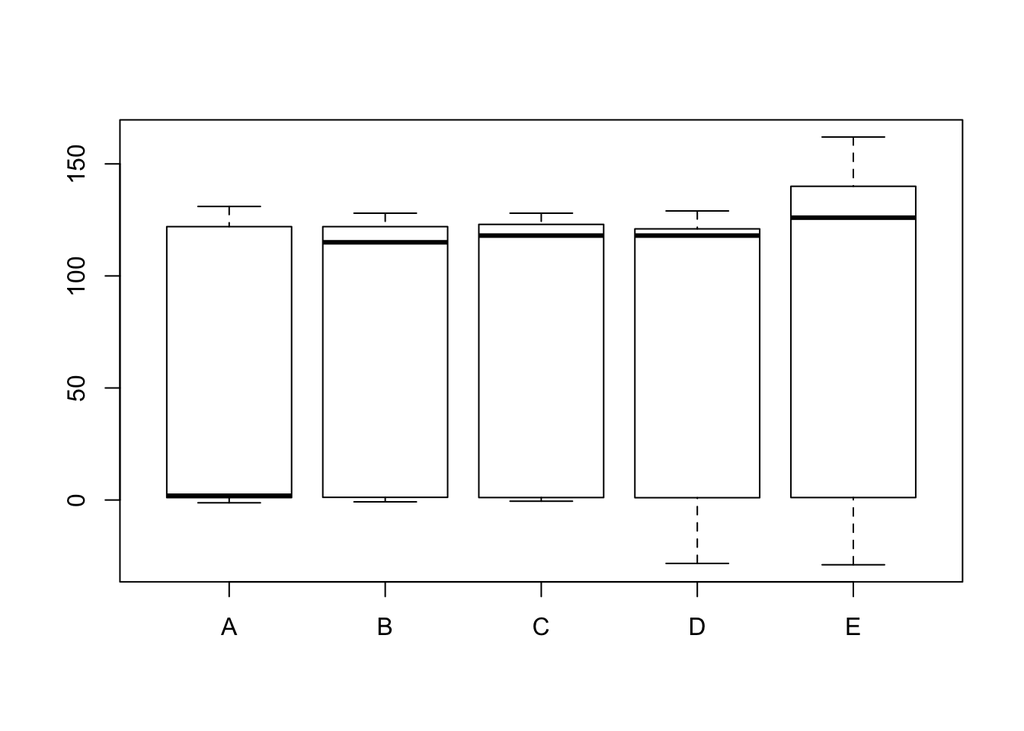

```r
plot(training$classe, training$roll_belt)
```

Also, as the 2 plots below show, their do not seem to be clear relationships between the roll and pitch measurements for a given sensor (belt in plot1) or between sensors for a given Eular angle (plot2).

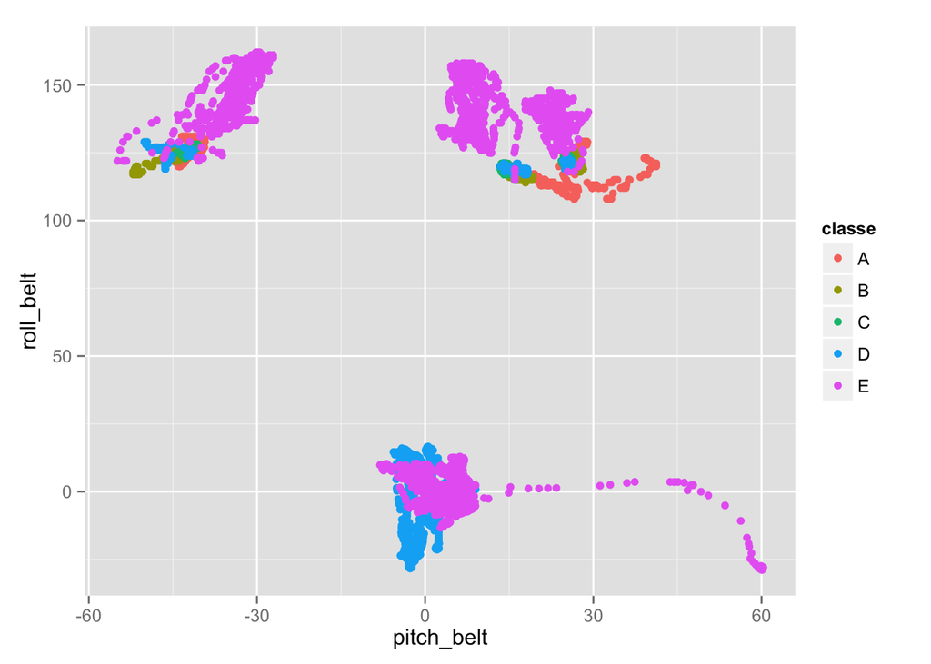

```r
library(ggplot2)
qplot(pitch_belt, roll_belt, colour=classe, data=training)
```

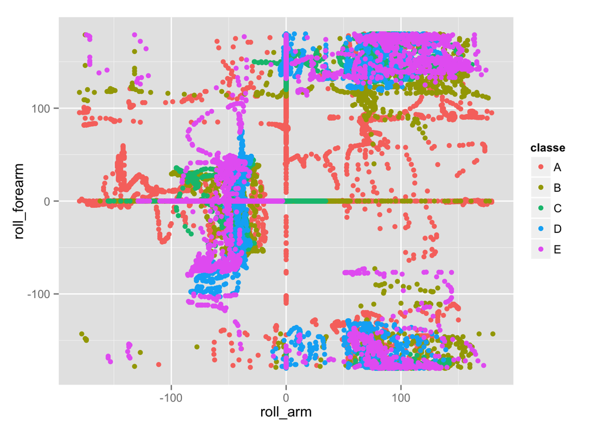

```r
qplot(roll_arm, roll_forearm, colour=classe, data=training)
```

Both the training and testing sets were therefore subset to only include these pitch and roll columns.

```r
cols <- c("classe",
          "pitch_belt", "roll_belt",
          "pitch_arm", "roll_arm",
          "pitch_forearm", "roll_forearm",
          "pitch_dumbbell", "roll_dumbbell")

training <- training[, cols]
testing <- testing[, cols]
```

### Model

A model was developed using the subsetted training set with the pitch and roll variables. A Random Forest model was used.

```r
set.seed(1)
modfit <- train(classe ~ ., method="rf", data=training)
print(modfit)
```

```
## Random Forest
##
## 14718 samples
##     8 predictor
##     5 classes: 'A', 'B', 'C', 'D', 'E'
##
## No pre-processing
## Resampling: Bootstrapped (25 reps)
##
## Summary of sample sizes: 14718, 14718, 14718, 14718, 14718, 14718, ...
##
## Resampling results across tuning parameters:
##
##   mtry  Accuracy  Kappa  Accuracy SD  Kappa SD
##   2     1         1.0    0.003        0.003
##   5     1         1.0    0.002        0.003
##   8     1         0.9    0.003        0.004
##
## Accuracy was used to select the optimal model using  the largest value.
## The final value used for the model was mtry = 2.
```

Next, the model is used to predict the classe in our testing set. The table shows how many of the predictions were correct across classes in the testing set.

```r
pred <- predict(modfit, testing)
testing$predright <- pred==testing$classe
table(pred, testing$classe)
```

```
##
## pred    A    B    C    D    E
##    A 1382   13    0    0    0
##    B    7  899    2    5    5
##    C    2   25  832   11    8
##    D    3    9   18  788    8
##    E    1    3    3    0  880
```

```r
inerr <- 1 - round(sum(testing$predright)/length(testing$predright),2)
```

The sample error for the model is 0.03. The out of sample error is expected to be greater.

By looking at the roll arm and forearm data, many of the incorrect predictions are grouped together in the upper right quadrant, which had overlaps of all 4 cases in the previously shown plot of the training set.

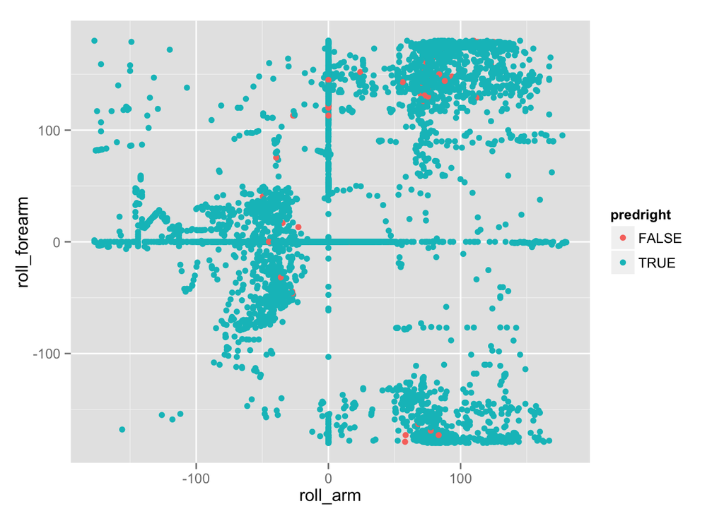

```r
qplot(roll_arm, roll_forearm, colour=predright, data=testing)
```

### Test cases

Finally, the model was used to predict the 20 test cases in the oringinal test dataset.

```r
tpred <- predict(modfit, test20)
test20$predict <- tpred
print(test20[,c("X", "predict")])
```

```
##     X predict
## 1   1       B
## 2   2       A
## 3   3       B
## 4   4       A
## 5   5       A
## 6   6       E
## 7   7       D
## 8   8       B
## 9   9       A
## 10 10       A
## 11 11       B
## 12 12       C
## 13 13       B
## 14 14       A
## 15 15       E
## 16 16       E
## 17 17       A
## 18 18       B
## 19 19       B
## 20 20       B
```